# DS & ML for (titanic)

```
      hello , in this project I will try to make prediction number of survivors people
            from titanic accident by supervised ml , some steps and explanation
```

first I will import libraries that i need to my project

```python
import pandas as pd
import numpy as np
import matplotlib.pyplot as plt
import seaborn as sns
%matplotlib inline
```

next I will import the database

```python
tittv = pd.read_csv('train.csv')
tittv
```

|  | PassengerId | Survived | Pclass | Name | Sex | Age | SibSp | Parch | Ticket | Fare | Cabin | Embarked |
| --- | --- | --- | --- | --- | --- | --- | --- | --- | --- | --- | --- | --- |
| 0 | 1 | 0 | 3 | Braund, Mr. Owen Harris | male | 22.0 | 1 | 0 | A/5 21171 | 7.2500 | NaN | S |
| 1 | 2 | 1 | 1 | Cumings, Mrs. John Bradley (Florence Briggs Th... | female | 38.0 | 1 | 0 | PC 17599 | 71.2833 | C85 | C |
| 2 | 3 | 1 | 3 | Heikkinen, Miss. Laina | female | 26.0 | 0 | 0 | STON/O2. 3101282 | 7.9250 | NaN | S |
| 3 | 4 | 1 | 1 | Futrelle, Mrs. Jacques Heath (Lily May Peel) | female | 35.0 | 1 | 0 | 113803 | 53.1000 | C123 | S |
| 4 | 5 | 0 | 3 | Allen, Mr. William Henry | male | 35.0 | 0 | 0 | 373450 | 8.0500 | NaN | S |
| ... | ... | ... | ... | ... | ... | ... | ... | ... | ... | ... | ... | ... |
| 886 | 887 | 0 | 2 | Montvila, Rev. Juozas | male | 27.0 | 0 | 0 | 211536 | 13.0000 | NaN | S |
| 887 | 888 | 1 | 1 | Graham, Miss. Margaret Edith | female | 19.0 | 0 | 0 | 112053 | 30.0000 | B42 | S |
| 888 | 889 | 0 | 3 | Johnston, Miss. Catherine Helen "Carrie" | female | NaN | 1 | 2 | W./C. 6607 | 23.4500 | NaN | S |
| 889 | 890 | 1 | 1 | Behr, Mr. Karl Howell | male | 26.0 | 0 | 0 | 111369 | 30.0000 | C148 | C |
| 890 | 891 | 0 | 3 | Dooley, Mr. Patrick | male | 32.0 | 0 | 0 | 370376 | 7.7500 | NaN | Q |

891 rows × 12 columns

to understand the database more I will make inspecting of data

```python
tittv.info()
```

```
<class 'pandas.core.frame.DataFrame'>
RangeIndex: 891 entries, 0 to 890
Data columns (total 12 columns):
 #   Column       Non-Null Count  Dtype
---  ------       --------------  -----
 0   PassengerId  891 non-null    int64
 1   Survived     891 non-null    int64
 2   Pclass       891 non-null    int64
 3   Name         891 non-null    object
 4   Sex          891 non-null    object
 5   Age          714 non-null    float64
 6   SibSp        891 non-null    int64
 7   Parch        891 non-null    int64
 8   Ticket       891 non-null    object
 9   Fare         891 non-null    float64
 10  Cabin        204 non-null    object
 11  Embarked     889 non-null    object
dtypes: float64(2), int64(5), object(5)
memory usage: 83.7+ KB
```

```python
tittv.describe().round(1)
```

|  | PassengerId | Survived | Pclass | Age | SibSp | Parch | Fare |
| --- | --- | --- | --- | --- | --- | --- | --- |
| count | 891.0 | 891.0 | 891.0 | 714.0 | 891.0 | 891.0 | 891.0 |
| mean | 446.0 | 0.4 | 2.3 | 29.7 | 0.5 | 0.4 | 32.2 |
| std | 257.4 | 0.5 | 0.8 | 14.5 | 1.1 | 0.8 | 49.7 |
| min | 1.0 | 0.0 | 1.0 | 0.4 | 0.0 | 0.0 | 0.0 |
| 25% | 223.5 | 0.0 | 2.0 | 20.1 | 0.0 | 0.0 | 7.9 |
| 50% | 446.0 | 0.0 | 3.0 | 28.0 | 0.0 | 0.0 | 14.5 |
| 75% | 668.5 | 1.0 | 3.0 | 38.0 | 1.0 | 0.0 | 31.0 |
| max | 891.0 | 1.0 | 3.0 | 80.0 | 8.0 | 6.0 | 512.3 |

I noticed from inspecting of data columns (Name, Sex, Ticket ) are objects, and ML will not understand them so I need to make preprocessingand data cleaning

```python
tittv.isna().sum()
```

```
PassengerId      0
Survived         0
Pclass           0
Name             0
Sex              0
Age            177
SibSp            0
Parch            0
Ticket           0
Fare             0
Cabin          687
Embarked         2
dtype: int64
```

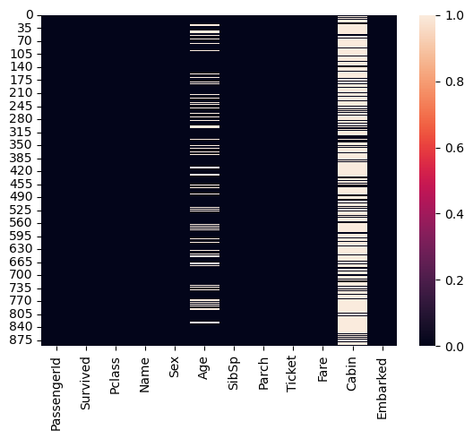

```python
sns.heatmap(tittv.isna())
```

```python
tittv ['Age'] = tittv ['Age'].fillna(tittv ['Age'].mean())
```

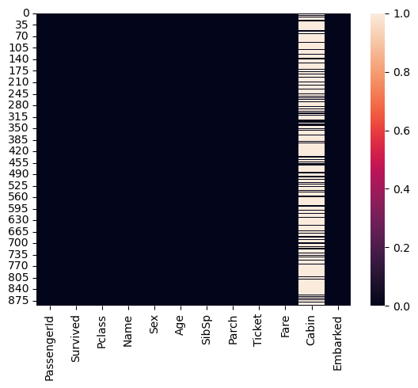

```python
sns.heatmap(tittv.isna())
```

```python
tittv.drop('Cabin',axis=1, inplace= True)
```

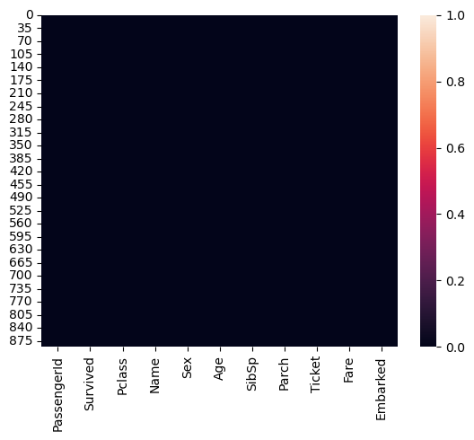

```python
sns.heatmap(tittv.isna())
```

```
  but still have problem for Sex column
```

```python
tittv['Sex'].value_counts()
```

```
male      577
female    314
Name: Sex, dtype: int64
```

```python
tittv['Embarked'].value_counts()
```

```
S    644
C    168
Q     77
Name: Embarked, dtype: int64
```

```python
gender = pd.get_dummies(tittv['Sex'],drop_first = True)
gender
```

|  | male |
| --- | --- |
| 0 | 1 |
| 1 | 0 |
| 2 | 0 |
| 3 | 0 |
| 4 | 1 |
| ... | ... |
| 886 | 1 |
| 887 | 0 |
| 888 | 0 |
| 889 | 1 |
| 890 | 1 |

891 rows × 1 columns

```python
emp = pd.get_dummies(tittv['Embarked'])
emp
```

|  | C | Q | S |
| --- | --- | --- | --- |
| 0 | 0 | 0 | 1 |
| 1 | 1 | 0 | 0 |
| 2 | 0 | 0 | 1 |
| 3 | 0 | 0 | 1 |
| 4 | 0 | 0 | 1 |
| ... | ... | ... | ... |
| 886 | 0 | 0 | 1 |
| 887 | 0 | 0 | 1 |
| 888 | 0 | 0 | 1 |
| 889 | 1 | 0 | 0 |
| 890 | 0 | 1 | 0 |

891 rows × 3 columns

```python
tittv['Sex']= gender
```

```python
tittv
```

|  | PassengerId | Survived | Pclass | Name | Sex | Age | SibSp | Parch | Ticket | Fare | Embarked |
| --- | --- | --- | --- | --- | --- | --- | --- | --- | --- | --- | --- |
| 0 | 1 | 0 | 3 | Braund, Mr. Owen Harris | 1 | 22.000000 | 1 | 0 | A/5 21171 | 7.2500 | S |
| 1 | 2 | 1 | 1 | Cumings, Mrs. John Bradley (Florence Briggs Th... | 0 | 38.000000 | 1 | 0 | PC 17599 | 71.2833 | C |
| 2 | 3 | 1 | 3 | Heikkinen, Miss. Laina | 0 | 26.000000 | 0 | 0 | STON/O2. 3101282 | 7.9250 | S |
| 3 | 4 | 1 | 1 | Futrelle, Mrs. Jacques Heath (Lily May Peel) | 0 | 35.000000 | 1 | 0 | 113803 | 53.1000 | S |
| 4 | 5 | 0 | 3 | Allen, Mr. William Henry | 1 | 35.000000 | 0 | 0 | 373450 | 8.0500 | S |
| ... | ... | ... | ... | ... | ... | ... | ... | ... | ... | ... | ... |
| 886 | 887 | 0 | 2 | Montvila, Rev. Juozas | 1 | 27.000000 | 0 | 0 | 211536 | 13.0000 | S |
| 887 | 888 | 1 | 1 | Graham, Miss. Margaret Edith | 0 | 19.000000 | 0 | 0 | 112053 | 30.0000 | S |
| 888 | 889 | 0 | 3 | Johnston, Miss. Catherine Helen "Carrie" | 0 | 29.699118 | 1 | 2 | W./C. 6607 | 23.4500 | S |
| 889 | 890 | 1 | 1 | Behr, Mr. Karl Howell | 1 | 26.000000 | 0 | 0 | 111369 | 30.0000 | C |
| 890 | 891 | 0 | 3 | Dooley, Mr. Patrick | 1 | 32.000000 | 0 | 0 | 370376 | 7.7500 | Q |

891 rows × 11 columns

```python
tittv= pd.concat([tittv,emp],axis = 1 )
```

```python
tittv
```

|  | PassengerId | Survived | Pclass | Name | Sex | Age | SibSp | Parch | Ticket | Fare | Embarked | C | Q | S |
| --- | --- | --- | --- | --- | --- | --- | --- | --- | --- | --- | --- | --- | --- | --- |
| 0 | 1 | 0 | 3 | Braund, Mr. Owen Harris | 1 | 22.000000 | 1 | 0 | A/5 21171 | 7.2500 | S | 0 | 0 | 1 |
| 1 | 2 | 1 | 1 | Cumings, Mrs. John Bradley (Florence Briggs Th... | 0 | 38.000000 | 1 | 0 | PC 17599 | 71.2833 | C | 1 | 0 | 0 |
| 2 | 3 | 1 | 3 | Heikkinen, Miss. Laina | 0 | 26.000000 | 0 | 0 | STON/O2. 3101282 | 7.9250 | S | 0 | 0 | 1 |
| 3 | 4 | 1 | 1 | Futrelle, Mrs. Jacques Heath (Lily May Peel) | 0 | 35.000000 | 1 | 0 | 113803 | 53.1000 | S | 0 | 0 | 1 |
| 4 | 5 | 0 | 3 | Allen, Mr. William Henry | 1 | 35.000000 | 0 | 0 | 373450 | 8.0500 | S | 0 | 0 | 1 |
| ... | ... | ... | ... | ... | ... | ... | ... | ... | ... | ... | ... | ... | ... | ... |
| 886 | 887 | 0 | 2 | Montvila, Rev. Juozas | 1 | 27.000000 | 0 | 0 | 211536 | 13.0000 | S | 0 | 0 | 1 |
| 887 | 888 | 1 | 1 | Graham, Miss. Margaret Edith | 0 | 19.000000 | 0 | 0 | 112053 | 30.0000 | S | 0 | 0 | 1 |
| 888 | 889 | 0 | 3 | Johnston, Miss. Catherine Helen "Carrie" | 0 | 29.699118 | 1 | 2 | W./C. 6607 | 23.4500 | S | 0 | 0 | 1 |
| 889 | 890 | 1 | 1 | Behr, Mr. Karl Howell | 1 | 26.000000 | 0 | 0 | 111369 | 30.0000 | C | 1 | 0 | 0 |
| 890 | 891 | 0 | 3 | Dooley, Mr. Patrick | 1 | 32.000000 | 0 | 0 | 370376 | 7.7500 | Q | 0 | 1 | 0 |

891 rows × 14 columns

```python
tittv.drop (['PassengerId','Name','Ticket','Embarked'], axis = 1 , inplace= True)
```

```python
tittv.rename(columns={'Sex':'Gender'},inplace = True)
```

```python
tittv
```

|  | Survived | Pclass | Gender | Age | SibSp | Parch | Fare | C | Q | S |
| --- | --- | --- | --- | --- | --- | --- | --- | --- | --- | --- |
| 0 | 0 | 3 | 1 | 22.000000 | 1 | 0 | 7.2500 | 0 | 0 | 1 |
| 1 | 1 | 1 | 0 | 38.000000 | 1 | 0 | 71.2833 | 1 | 0 | 0 |
| 2 | 1 | 3 | 0 | 26.000000 | 0 | 0 | 7.9250 | 0 | 0 | 1 |
| 3 | 1 | 1 | 0 | 35.000000 | 1 | 0 | 53.1000 | 0 | 0 | 1 |
| 4 | 0 | 3 | 1 | 35.000000 | 0 | 0 | 8.0500 | 0 | 0 | 1 |
| ... | ... | ... | ... | ... | ... | ... | ... | ... | ... | ... |
| 886 | 0 | 2 | 1 | 27.000000 | 0 | 0 | 13.0000 | 0 | 0 | 1 |
| 887 | 1 | 1 | 0 | 19.000000 | 0 | 0 | 30.0000 | 0 | 0 | 1 |
| 888 | 0 | 3 | 0 | 29.699118 | 1 | 2 | 23.4500 | 0 | 0 | 1 |
| 889 | 1 | 1 | 1 | 26.000000 | 0 | 0 | 30.0000 | 1 | 0 | 0 |
| 890 | 0 | 3 | 1 | 32.000000 | 0 | 0 | 7.7500 | 0 | 1 | 0 |

891 rows × 10 columns

# than I will make exploratory data analysis

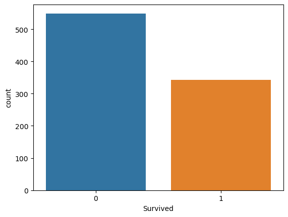

```python
sns.countplot(x='Survived',data= tittv)
```

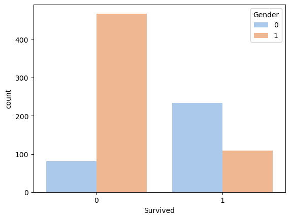

```python
sns.countplot(x='Survived',hue='Gender',data= tittv,palette='pastel')
```

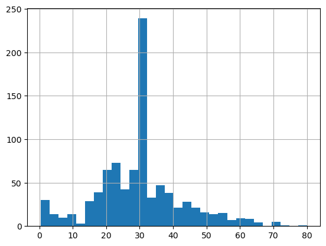

```python
tittv['Age'].hist(bins=30)
```

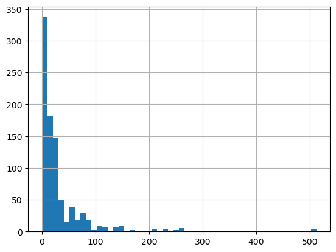

```python
tittv['Fare'].hist (bins = 50)
```

In the end from exploring the data I got some info :

1 / the first plot // the number of died more than Survived

2 / the second plot // when we looking for horizontal line we will get 0 = died , 1 = Survived , and you can specific the gander from the small box so : the number of dead (women are less than men), and the number of Surviving (women large than man)

4 / the last histogram // right skewed , and we have 1% outlier and most people paid the same fare almost